# EDA

Amruta Gumma

16 September 2017

# Univariate Plot Section

```
## [1] "Dataset variables"
```

```
##
## * X
## * fixed.acidity
## * volatile.acidity
## * citric.acid
## * residual.sugar
## * chlorides
## * free.sulfur.dioxide
## * total.sulfur.dioxide
## * density
## * pH
## * sulphates
## * alcohol
## * quality
## * rating
##
## <!-- end of list -->
```

```
## [1] "Dataset structure"
```

```
## 'data.frame':    1599 obs. of  14 variables:
##  $ X                   : int  1 2 3 4 5 6 7 8 9 10 ...
##  $ fixed.acidity       : num  7.4 7.8 7.8 11.2 7.4 7.4 7.9 7.3 7.8 7.5 ...
##  $ volatile.acidity    : num  0.7 0.88 0.76 0.28 0.7 0.66 0.6 0.65 0.58 0.5 ...
##  $ citric.acid         : num  0 0 0.04 0.56 0 0 0.06 0 0.02 0.36 ...
##  $ residual.sugar      : num  1.9 2.6 2.3 1.9 1.9 1.8 1.6 1.2 2 6.1 ...
##  $ chlorides           : num  0.076 0.098 0.092 0.075 0.076 0.075 0.069 0.065 0.073 0.071 ...
##  $ free.sulfur.dioxide : num  11 25 15 17 11 13 15 15 9 17 ...
##  $ total.sulfur.dioxide: num  34 67 54 60 34 40 59 21 18 102 ...
##  $ density             : num  0.998 0.997 0.997 0.998 0.998 ...
##  $ pH                  : num  3.51 3.2 3.26 3.16 3.51 3.51 3.3 3.39 3.36 3.35 ...
##  $ sulphates           : num  0.56 0.68 0.65 0.58 0.56 0.56 0.46 0.47 0.57 0.8 ...
##  $ alcohol             : num  9.4 9.8 9.8 9.8 9.4 9.4 9.4 10 9.5 10.5 ...
##  $ quality             : Ord.factor w/ 6 levels "3"<"4"<"5"<"6"<..: 3 3 3 4 3 3 3 5 5 3 ...
##  $ rating              : Ord.factor w/ 3 levels "bad"<"average"<..: 2 2 2 2 2 2 2 3 3 2 ...
```

```
##
## -------------------------------------------------------------------
##        X          fixed.acidity   volatile.acidity    citric.acid
## ---------------- --------------- ------------------ ---------------
##   Min.  : 1.0     Min.  : 4.60     Min.  :0.1200     Min.  :0.000
##
##  1st Qu.: 400.5   1st Qu.: 7.10    1st Qu.:0.3900    1st Qu.:0.090
##
##  Median : 800.0   Median : 7.90    Median :0.5200    Median :0.260
##
##   Mean : 800.0     Mean : 8.32      Mean :0.5278      Mean :0.271
##
##  3rd Qu.:1199.5   3rd Qu.: 9.20    3rd Qu.:0.6400    3rd Qu.:0.420
##
##  Max.  :1599.0    Max.  :15.90     Max.  :1.5800     Max.  :1.000
## -------------------------------------------------------------------
##
## Table: Dataset summary (continued below)
##
##
## -------------------------------------------------------------------------------
##  residual.sugar      chlorides      free.sulfur.dioxide   total.sulfur.dioxide
## ---------------- ----------------- --------------------- ----------------------
##  Min.  : 0.900    Min.  :0.01200       Min.  : 1.00           Min.  : 6.00
##
##  1st Qu.: 1.900   1st Qu.:0.07000      1st Qu.: 7.00         1st Qu.: 22.00
##
##  Median : 2.200   Median :0.07900      Median :14.00         Median : 38.00
##
##   Mean : 2.539     Mean :0.08747        Mean :15.87           Mean : 46.47
##
##  3rd Qu.: 2.600   3rd Qu.:0.09000      3rd Qu.:21.00         3rd Qu.: 62.00
##
##  Max.  :15.500    Max.  :0.61100       Max.  :72.00          Max.  :289.00
## -------------------------------------------------------------------------------
##
## Table: Table continues below
##
##
## ---------------------------------------------------------------------------
```

[output cut: 18 more lines]

```
## --------------
##     rating
## --------------
##    bad : 63
##
##  average:1319
##
##   good : 217
##
##       NA
##
##       NA
##
##       NA
## --------------
```

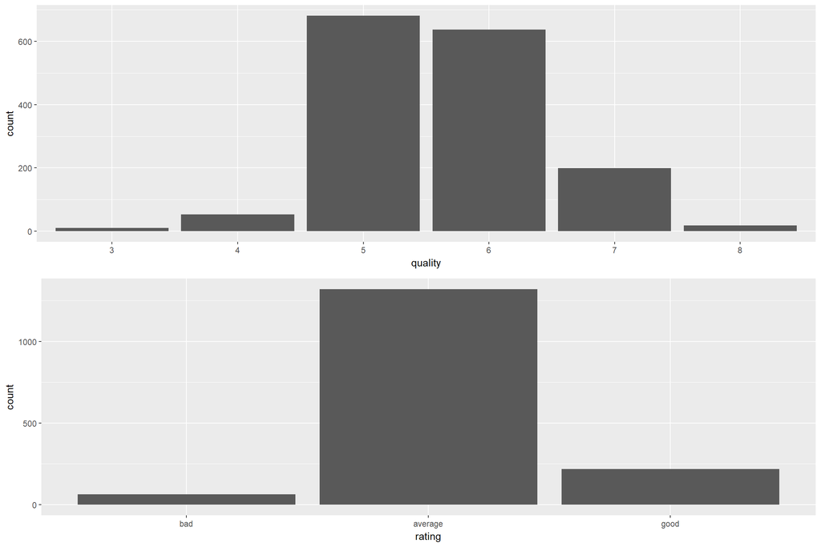

The high concentration of wines in both the cases is in the centre region as we can observe.

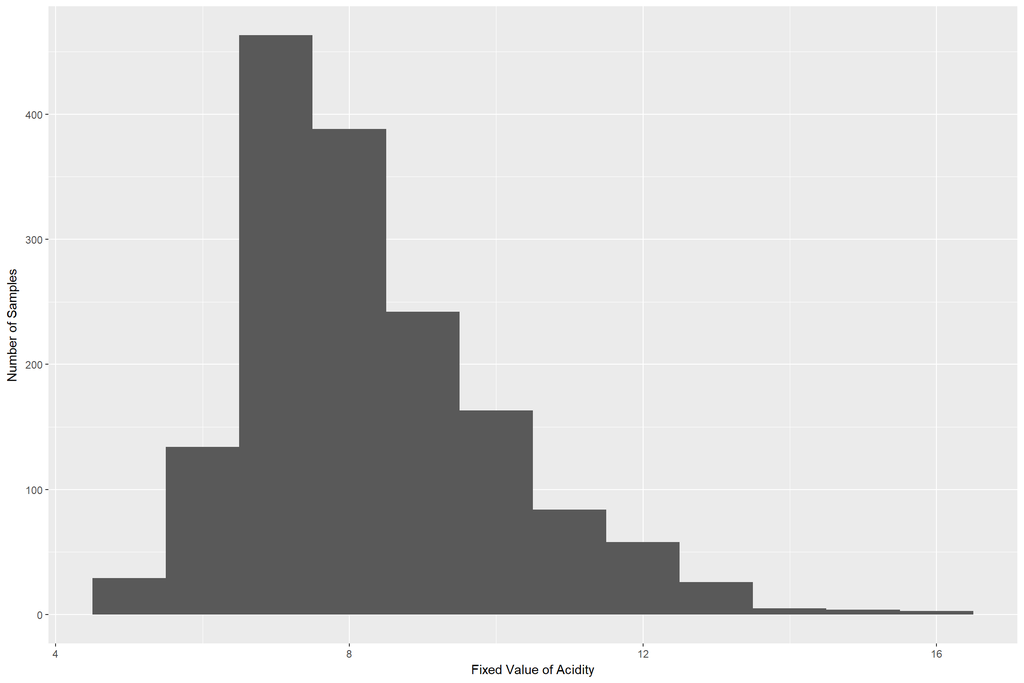

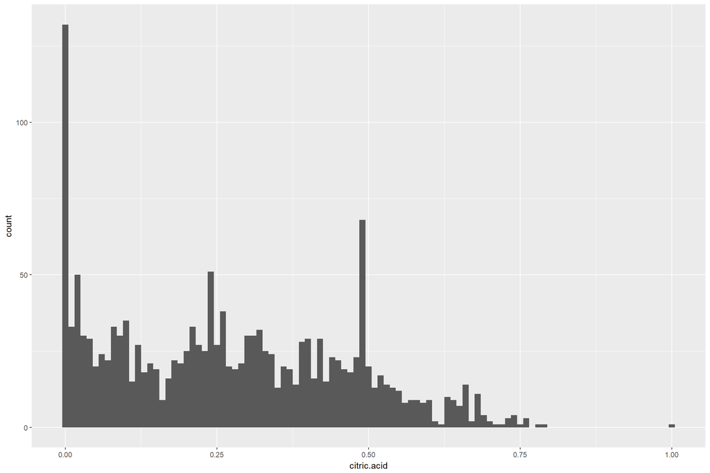

This is strange distribution. Some percentage of wines do not have critic acid at all.

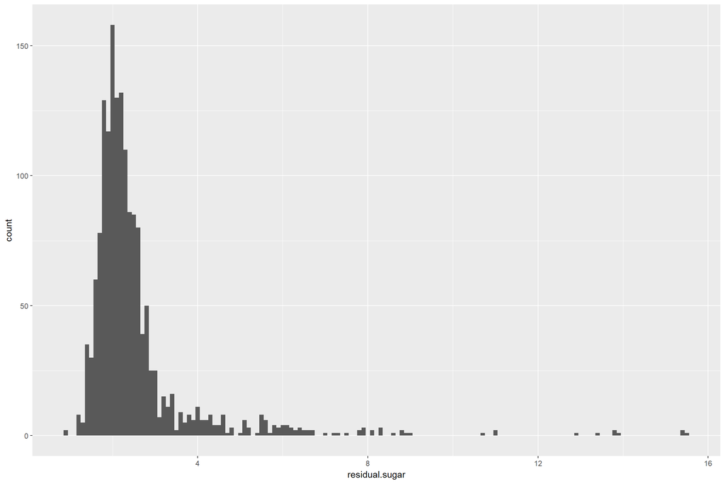

A high concentration of wines is around 2.2 (the median) with some outliers along the higher ranges.

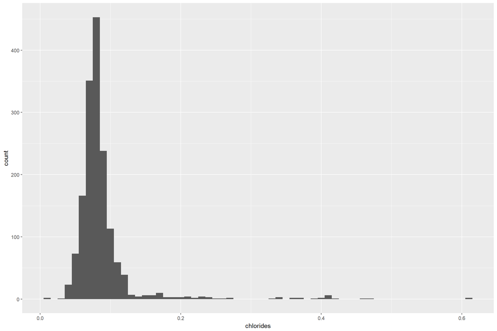

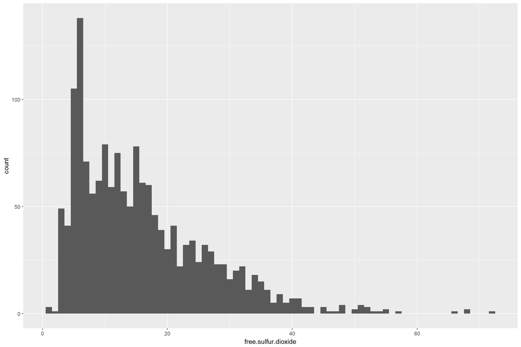

The distributions peaks at around 7 and from then on resembles a long tailed distribution with very few wines over 60.

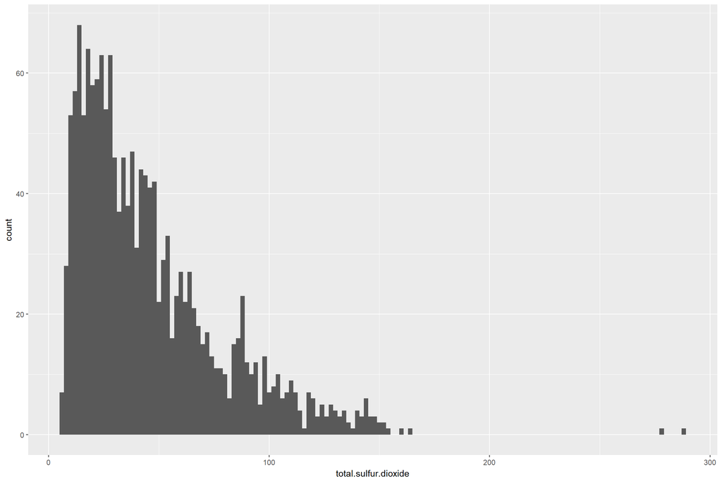

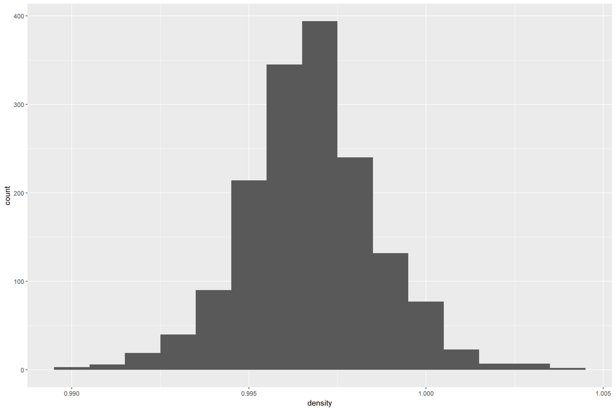

This distribution is almost symmetrical and pretty normal.

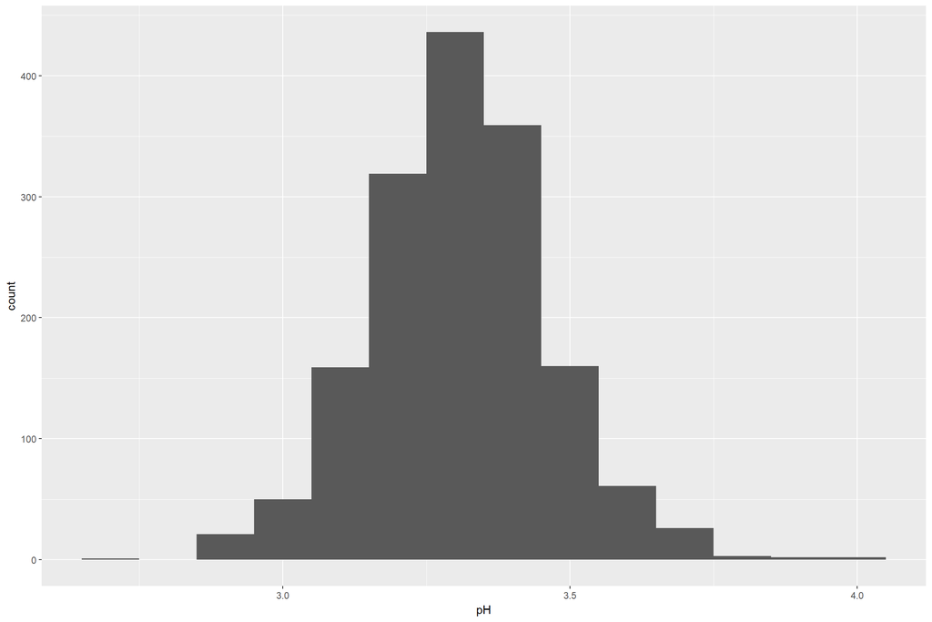

pH looks normally distributed

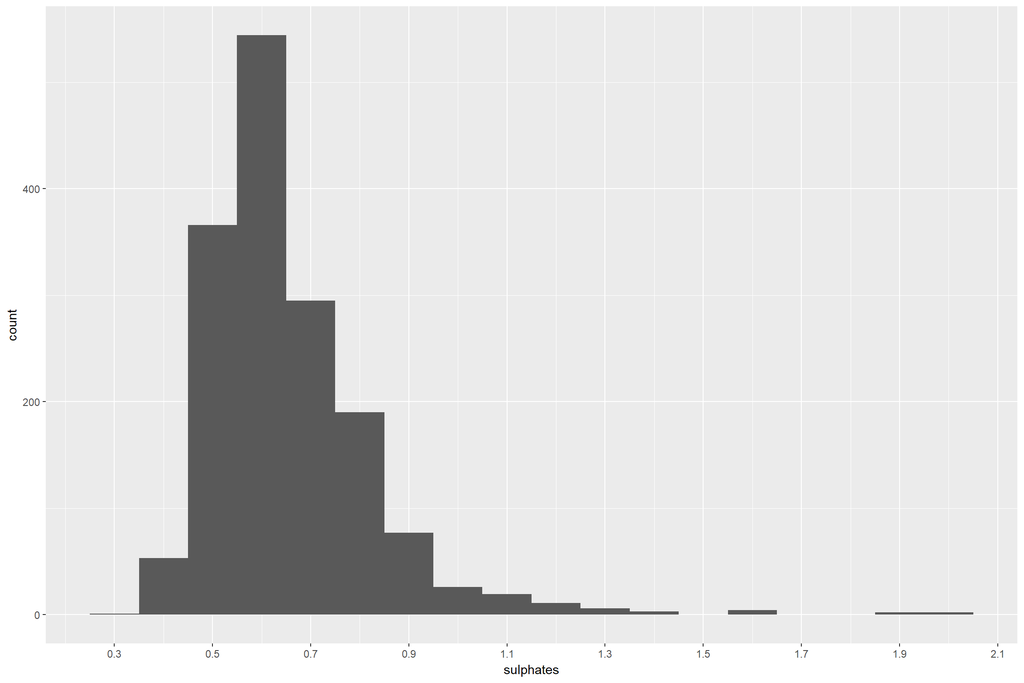

A high concentration of wines is around 0.6 (the median) with some outliers along the higher ranges.There is a rapid increase and then long tailed distribution

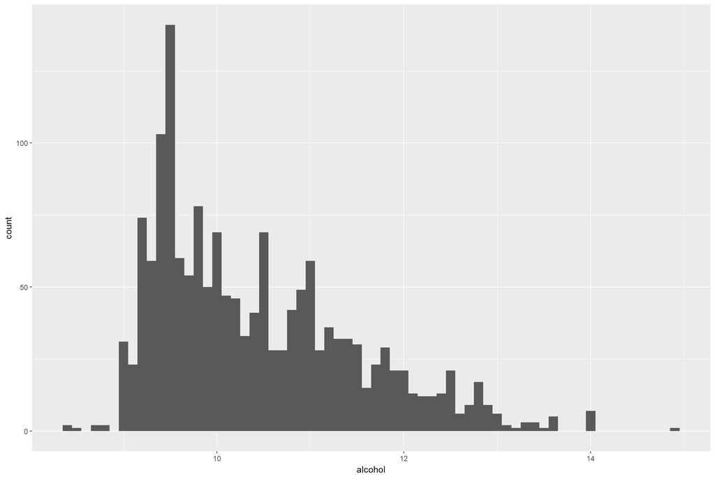

There is a rapid increase and then long tailed distribution as seen for sulphur dioxide.

# Univariate Analysis

### Other observations:

The median quality is 6, which in the given scale (1-10) is a mediocre wine. The better wine in the sample has a score of 8, and the worst has a score of 3. The dataset is not balanced, that is, there are a more average wines than poor or excelent ones.

### What is/are the main feature(s) of interest in your dataset?

The main feature in the data is quality and i would want to knnow which features determine the quality of wines.

### What other features in the dataset do you think will help support your investigation into your feature(s) of interest?

The variable residual.sugar dictates how sweet a wine is and might also have an influence in taste.The variables related to acidity (fixed, volatile, citric.acid and pH) might explain some of the variance.

### Did you create any new variables from existing variables in the dataset?

I created a rating variable to improvise the future visualizations.

### Of the features you investigated, were there any unusual distributions? Did

you perform any operations on the data to tidy, adjust, or change the form of the data? If so, why did you do this? Citric.acid stood out from the other distributions. 8% of the wines did not have the citric acid concentration at all which is unexpected.

# Bivariate Plots Section

Summarising using a box plot

### Relationship between qualitY and acid concentration

```
##
## --------------------------
##  quality   mean    median
## --------- ------- --------
##     3      8.36     7.5
##
##     4      7.779    7.5
##
##     5      8.167    7.8
##
##     6      8.347    7.9
##
##     7      8.872    8.8
##
##     8      8.567    8.25
## --------------------------
##
## Table: Summaries for fixed.acidity grouped by quality
```

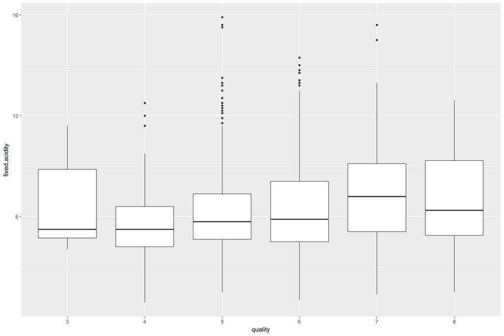

```
##
## ---------------------------
##  quality    mean    median
## --------- -------- --------
##     3      0.8845   0.845
##
##     4      0.694     0.67
##
##     5      0.577     0.58
##
##     6      0.4975    0.49
##
##     7      0.4039    0.37
##
##     8      0.4233    0.37
## ---------------------------
##
## Table: Summaries for volatile.acidity grouped by quality
```

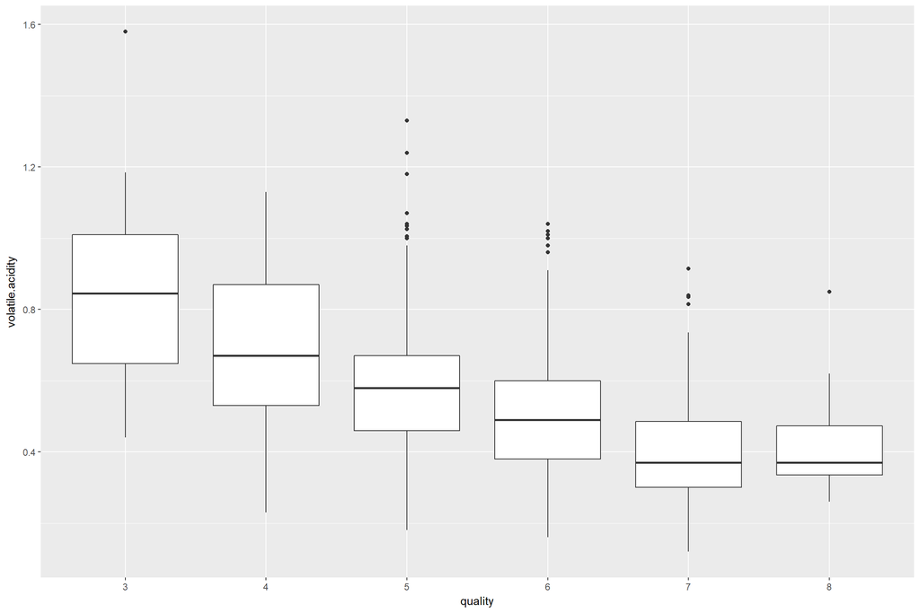

Quality seems to go up when volatile.acidity goes down. The higher ranges seem to produce more average and poor wines.

```
##
## --------------------------
##  quality   mean    median
## --------- ------- --------
##     3      2.635    2.1
##
##     4      2.694    2.1
##
##     5      2.529    2.2
##
##     6      2.477    2.2
##
##     7      2.721    2.3
##
##     8      2.578    2.1
## --------------------------
##
## Table: Summaries for residual.sugar grouped by quality
```

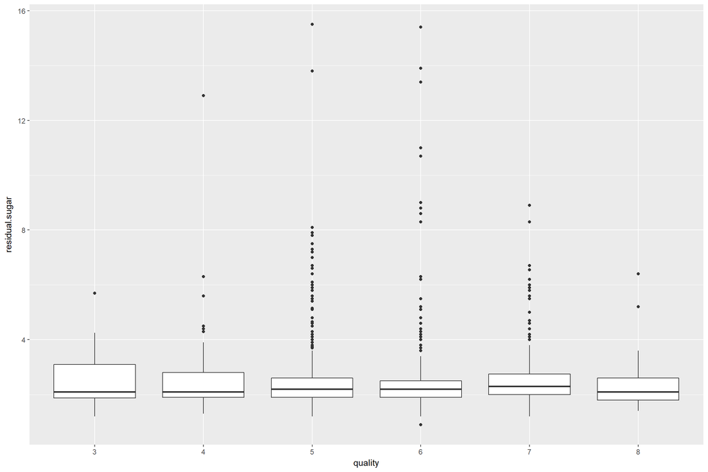

Sugar seems to have little effect on perceived quality.

```
##
## ----------------------------
##  quality    mean     median
## --------- --------- --------
##     3      0.1225    0.0905
##
##     4      0.09068    0.08
##
##     5      0.09274   0.081
##
##     6      0.08496   0.078
##
##     7      0.07659   0.073
##
##     8      0.06844   0.0705
## ----------------------------
##
## Table: Summaries for chlorides grouped by quality
```

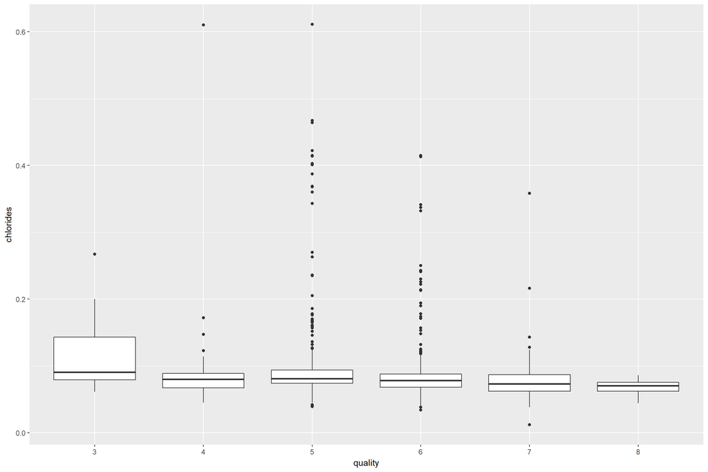

Altough weakly correlated, a lower concentration of chlorides seem to produce better wines.

```
##
## --------------------------
##  quality   mean    median
## --------- ------- --------
##     3       11       6
##
##     4      12.26     11
##
##     5      16.98     15
##
##     6      15.71     14
##
##     7      14.05     11
##
##     8      13.28    7.5
## --------------------------
##
## Table: Summaries for free.sulfur.dioxide grouped by quality
```

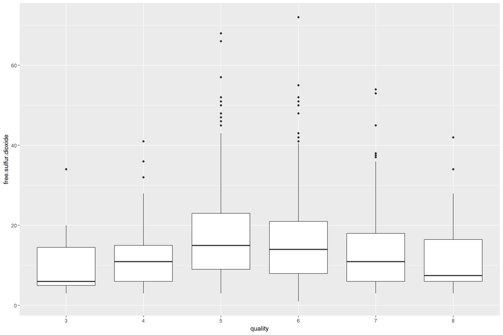

The ranges are really close to each other ,for little sulfur dioxide and we get a poor wine and for too much and we get an average wine.

```
##
## --------------------------
##  quality   mean    median
## --------- ------- --------
##     3      24.9      15
##
##     4      36.25     26
##
##     5      56.51     47
##
##     6      40.87     35
##
##     7      35.02     27
##
##     8      33.44    21.5
## --------------------------
##
## Table: Summaries for total.sulfur.dioxide grouped by quality
```

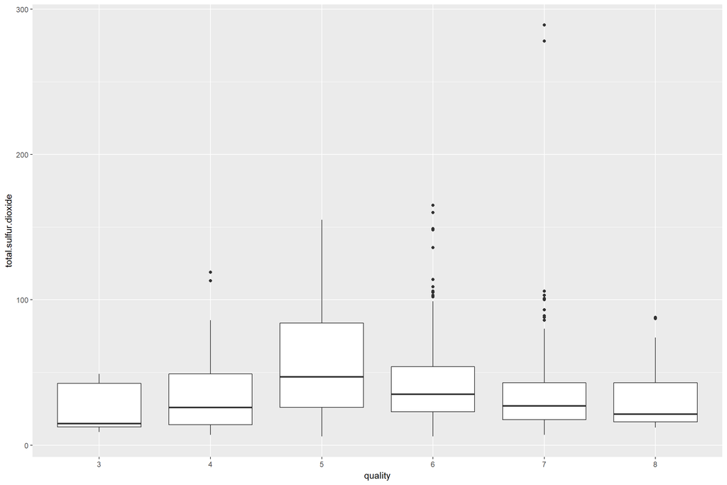

The distribution is similar to free.sulphur.dioxide

```
##
## ---------------------------
##  quality    mean    median
## --------- -------- --------
##     3      0.9975   0.9976
##
##     4      0.9965   0.9965
##
##     5      0.9971   0.997
##
##     6      0.9966   0.9966
##
##     7      0.9961   0.9958
##
##     8      0.9952   0.9949
## ---------------------------
##
## Table: Summaries for density grouped by quality
```

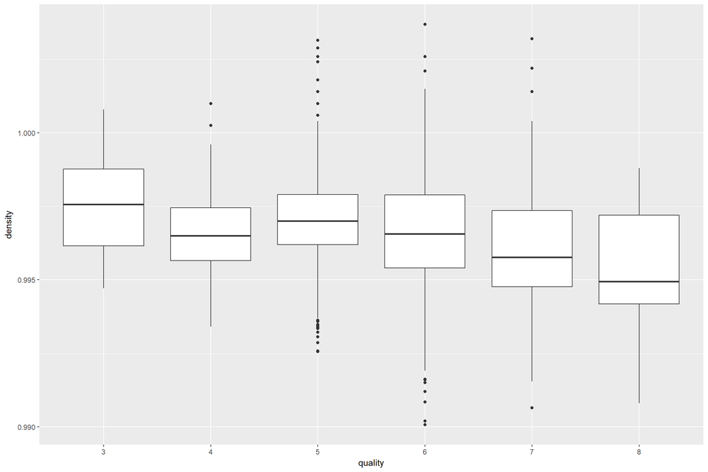

Better wines tend to have lower densities, but this is probably due to the alcohol concentration. I wonder if density still has an effect if we hold alcohol constant.

```
##
## --------------------------
##  quality   mean    median
## --------- ------- --------
##     3      3.398    3.39
##
##     4      3.382    3.37
##
##     5      3.305    3.3
##
##     6      3.318    3.32
##
##     7      3.291    3.28
##
##     8      3.267    3.23
## --------------------------
##
## Table: Summaries for pH grouped by quality
```

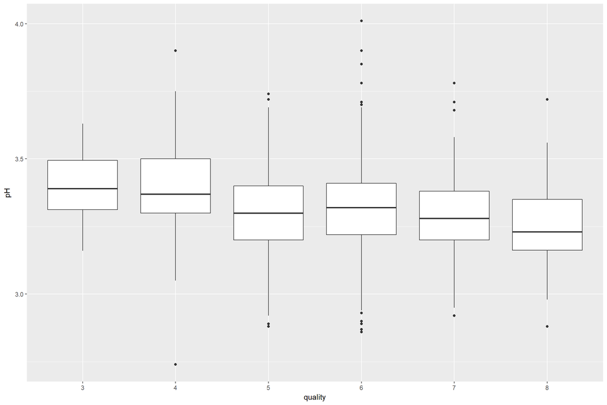

Altough there is definitely a trend (better wines being more acid) there are some outliers.I wonder how the distribution of the different acids affects this.

### Relationship between pH and acid concentration

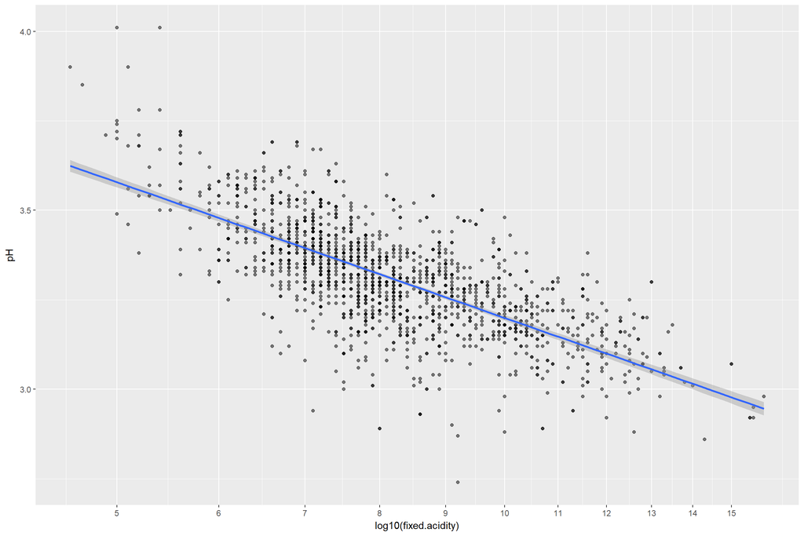

Negative correlation. The fixed.acidity decreases with increase in pH.

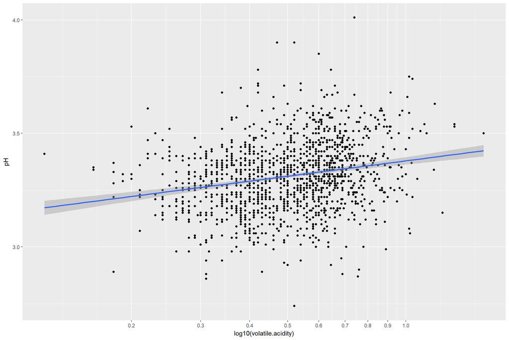

Positive correlation The concentration of volatile.acidity is concentrated more between 0.4 and 0.8.The higher ranges tend to have less concentration

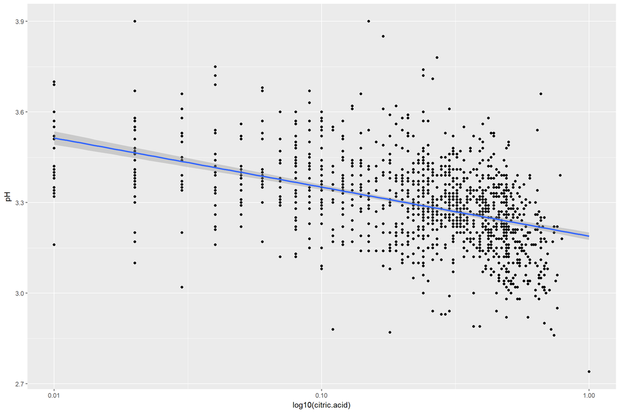

It is really strange that an acid concentration would have a positive correlation with pH.

We can investigate how much of the variance in pH these three acidity variables can explain using a linear model.

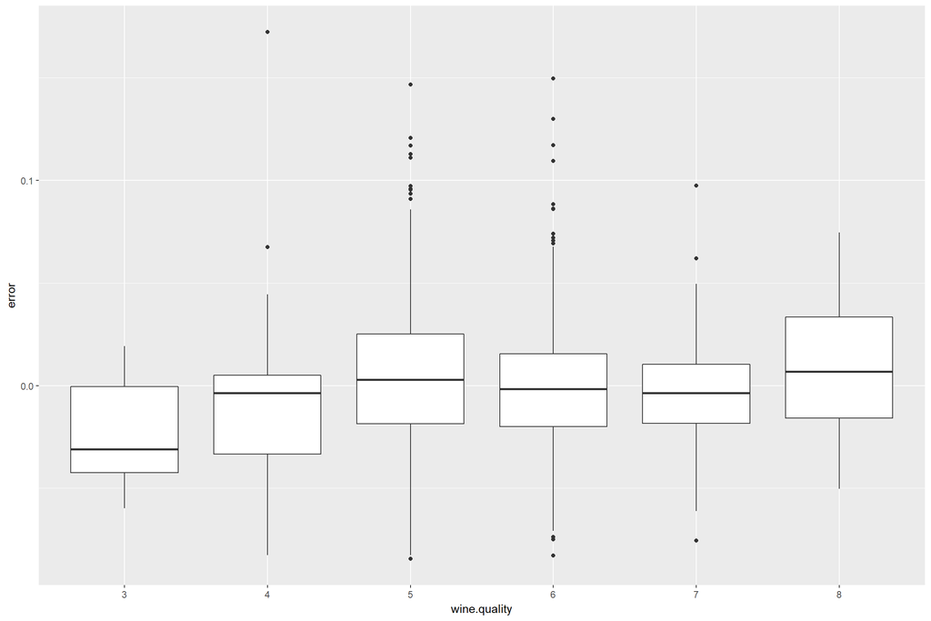

```
##
## ---------------------------
##  quality    mean    median
## --------- -------- --------
##     3       0.57    0.545
##
##     4      0.5964    0.56
##
##     5      0.621     0.58
##
##     6      0.6753    0.64
##
##     7      0.7413    0.74
##
##     8      0.7678    0.74
## ---------------------------
##
## Table: Summaries for sulphates grouped by quality
```

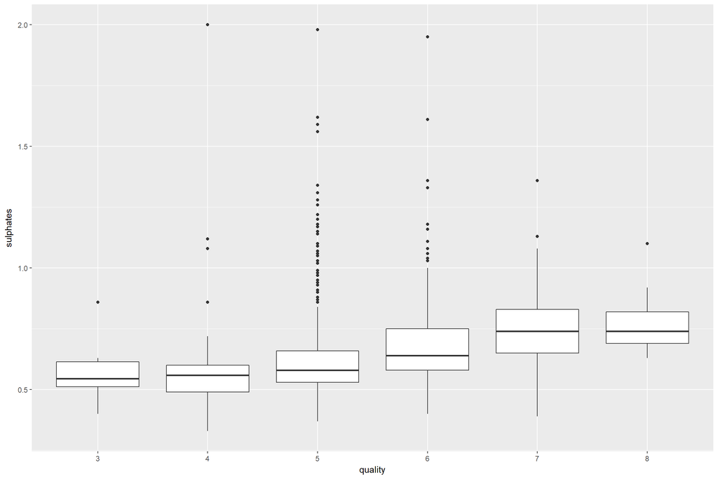

Altough there are many outliers in the medium wines, better wines seem to have a higher concentration of sulphates.

```
##
## --------------------------
##  quality   mean    median
## --------- ------- --------
##     3      9.955   9.925
##
##     4      10.27     10
##
##     5       9.9     9.7
##
##     6      10.63    10.5
##
##     7      11.47    11.5
##
##     8      12.09   12.15
## --------------------------
##
## Table: Summaries for alcohol grouped by quality
```

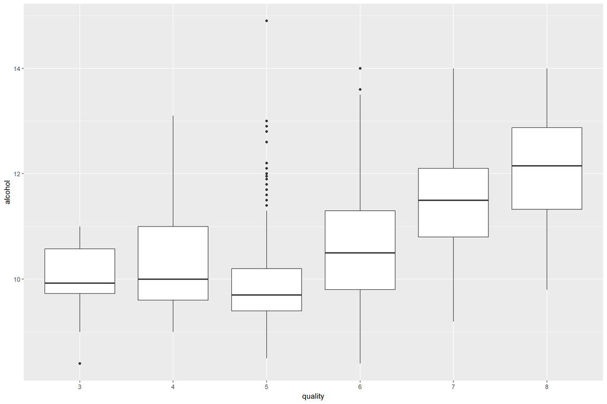

The correlation is clear here. With an increase in alcohol graduation we see an increase in the concentration of better graded wines. Given the high number of outliers it seems we cannot rely on alcohol alone to produce better wines.

# Bivariate Ananlysis

### Talk about some of the relationships you observed in this part of the investigation. How did the feature(s) of interest vary with other features in the dataset?

Fixed.acidity seems to have little to no effect on quality Quality seems to go up when volatile.acidity goes down. The higher ranges seem to produce more average and poor wines. Better wines tend to have higher concentration of citric acid. Contrary to what I initially expected residual.sugar apparently seems to have little to no effect on perceived quality. Altough weakly correlated, a lower concentration of chlorides seem to produce better wines. Better wines tend to have lower densities. In terms of pH it seems better wines are more acid but there were many outliers. Better wines also seem to have a higher concentration of sulphates.

### What was the strongest relationship you found?

# Multivariate Plots

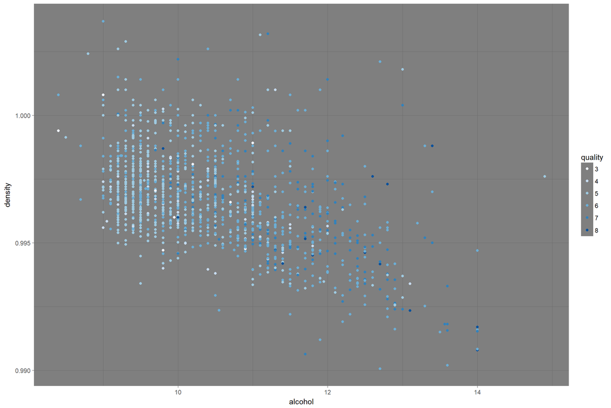

When we hold alcohol constant, there is no evidence that density affects quality which confirms our earlier suspicion.

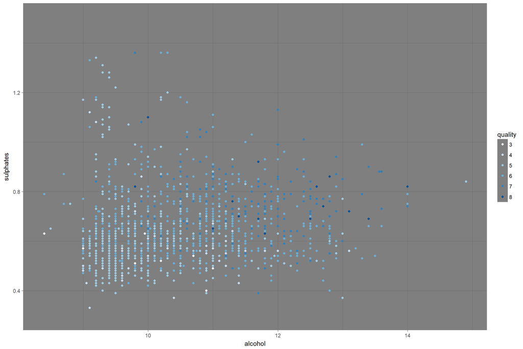

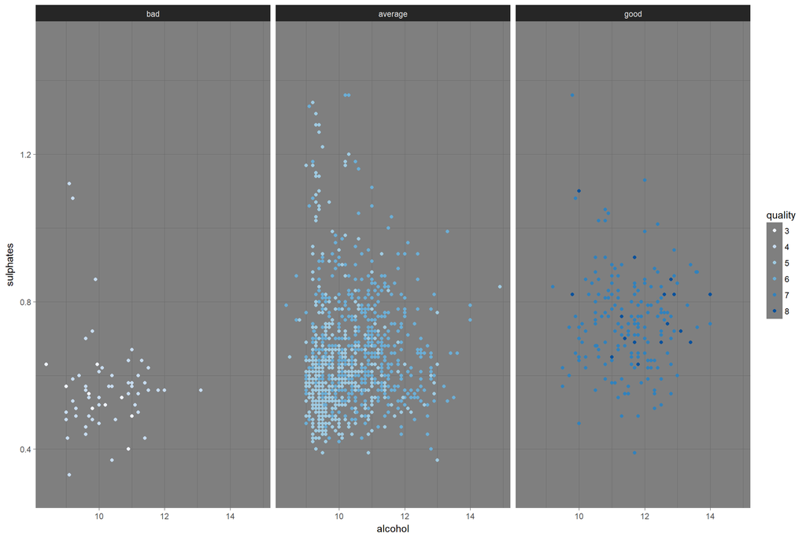

For wines with high alcohol content, having a higher concentration of sulphates produces better wines.

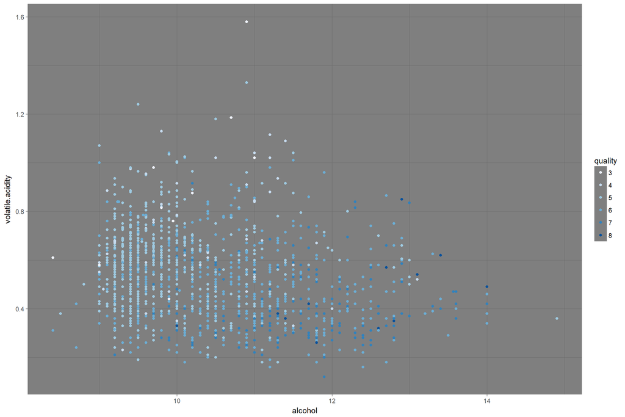

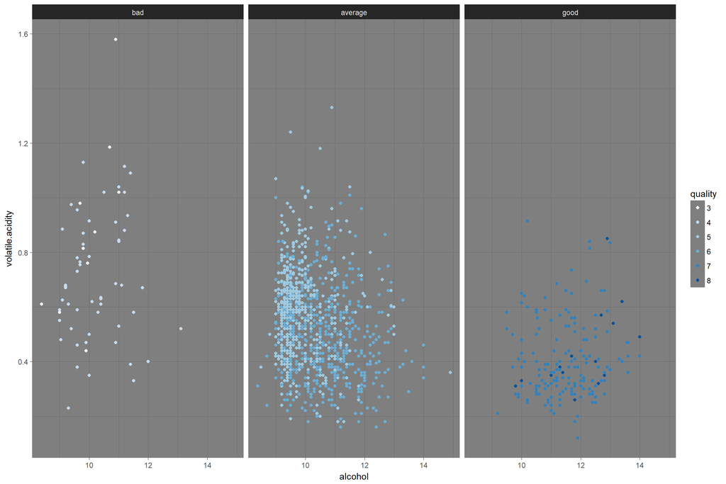

The reverse seems to be true for volatile acidity. Having less acetic acid on higher concentration of alcohol seems to produce better wines.

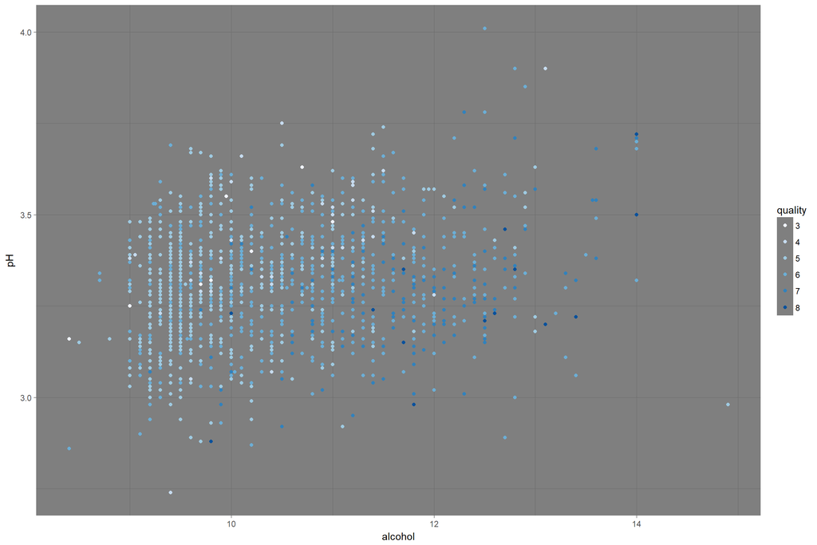

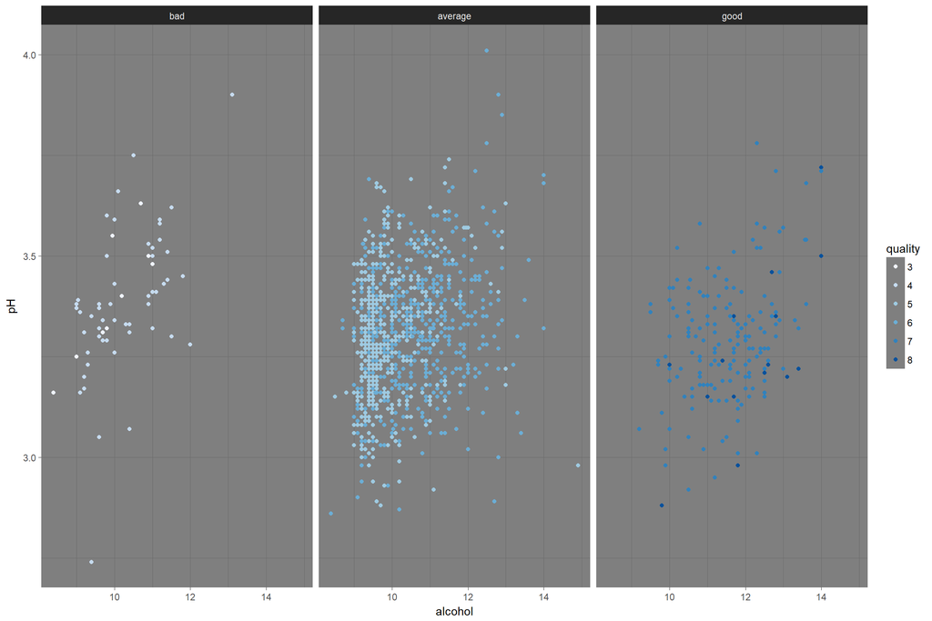

Low pH and high alcohol concentration seem to be a good combination.